# Prosper's Loan Data Exploration

## by: Satrio Putra

## Preliminary Wrangling

> This document explores a dataset containing borrower cost of credit and attributes for approximately 113,000 borrowers.

### Structure of the dataset

> Variable ProsperRating (Alpha) is ordered factor variables with the following levels. (worst) ——> (best)  
> ProsperRating (Alpha): HR, E, D, C, B, A, AA

### Main feature(s) of interest in the dataset

> What i am going to do is searching for variables that are affecting the borrower’s APR.

### What features in the dataset do you think will help support your investigation into your feature(s) of interest?

> I expect that Term and credit score will have the strongest effect on each borrower's APR: the longer the term, the higher the APR, the higher credit score, the lower APR. I also think that the ProsperScore, Employment status, and home ownership, will have effects on the interest, though to a much smaller degree than the main effect of Term.

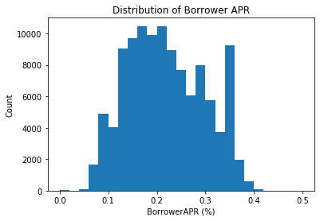

```python
#Plotting BorrowerAPR
bins = np.arange(0, 0.5+0.02, 0.02)
plt.hist(data = df, x = 'BorrowerAPR', bins=bins)
plt.xlabel('BorrowerAPR (%)')
plt.title('Distribution of Borrower APR')
plt.ylabel('Count');
```

As we can see on the plot, Borrower APR is correlated with credit score. But, I thought that credit score is more correlated with APR better than other variables.

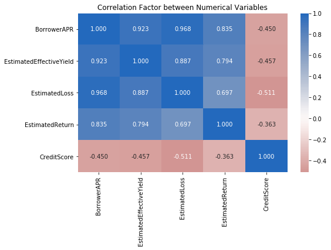

```python
# correlation plot
plt.figure(figsize = [8, 5])
sb.heatmap(df[numeric_vars].corr(), annot = True, fmt = '.3f',
           cmap = 'vlag_r', center = 0)
plt.title('Correlation Factor between Numerical Variables')
plt.show()
```

This variable is what i though to be the best predictor of borrower APR. But as we can see in the plot above, relationship between credit score and borrower APR is not clear. That is why i added regression plot to help understanding the relationship between two variables above.

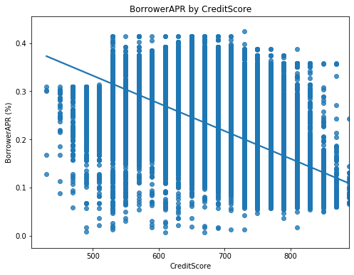

```python
plt.figure(figsize = [8, 6])
sb.regplot(data = df, x = 'CreditScore', y = 'BorrowerAPR')
# plt.xlim([0, 3.5])
plt.xlabel('CreditScore')
plt.ylabel('BorrowerAPR (%)')
plt.title('BorrowerAPR by CreditScore')
plt.show();
```

We can see that credit score shows better correlation with borrower APR in higher Prosper score category than the lower in all borrowing term. In the lower score category, the plot is spreaded and makes the relationship unclear.

```python
df1 = df.query('ProsperScore == 1 or ProsperScore == 10')
```

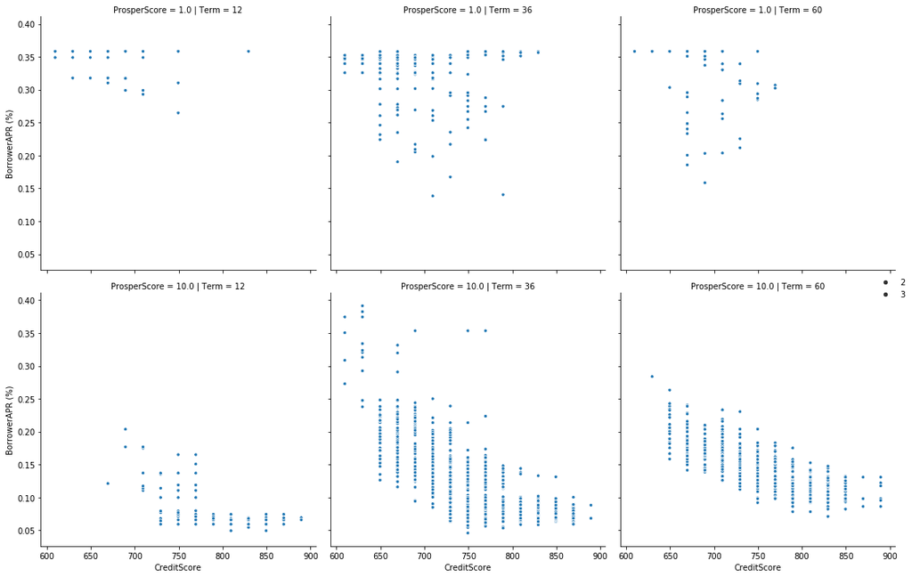

```python
g = sb.relplot(data = df1, x = 'CreditScore', y ='BorrowerAPR' , col= 'Term', row ='ProsperScore' , size = 3)
# g = (g.map(plt.scatter, 'CreditScore', 'BorrowerAPR')).add_legend()
g.set_xlabels('CreditScore')
g.set_ylabels('BorrowerAPR (%)')
g.add_legend();
```

```python
df1 = df.query('ProsperScore == 1 or ProsperScore == 10')
```

[figure not shown]

```python
g = sb.relplot(data = df1, x = 'EstimatedLoss', y ='BorrowerAPR' , col= 'Term', row ='ProsperScore', size = 3)
# g = (g.map(plt.scatter, 'CreditScore', 'BorrowerAPR')).add_legend()
g.set_xlabels('EstimatedLoss (%)')
g.set_ylabels('BorrowerAPR (%)')
g.add_legend();
```

There is no clear distinction of borrowing APR between 12-months, 36-months, and 60-months borrowing term for people in the lowest Prosper score, while you can find regularity in the plot for highest Prosper score. We can see that there is clear distance between the terms in highest score category. It is also interesting that people can get lower APR for 60-months for the first lending and the fourth lending in lowest score category.

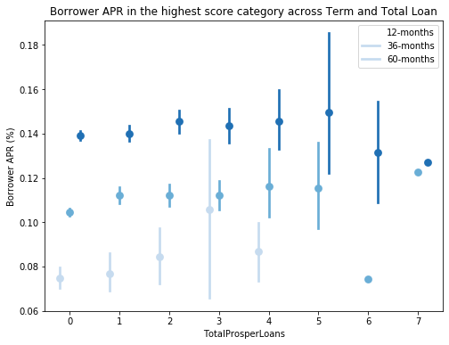

```python
fig = plt.figure(figsize = [8,6])
ax = sb.pointplot(data = df_score_max, x = 'TotalProsperLoans', y = 'BorrowerAPR', hue = 'Term',
           palette = 'Blues', linestyles = '', dodge = 0.4)
plt.title('Borrower APR in the highest score category across Term and Total Loan')
plt.ylabel('Borrower APR (%)')
plt.legend(['12-months', '36-months', '60-months']);
```

[figure not shown]

```python
fig = plt.figure(figsize = [8,6])
ax = sb.pointplot(data = df_score_max, x = 'TotalProsperLoans', y = 'BorrowerAPR', hue = 'Term',
           palette = 'Blues', linestyles = '', dodge = 0.4)
plt.title('Borrower APR in the lowest score category across Term and Total Loan')
plt.ylabel('Borrower APR (%)')
plt.legend(['12-months', '36-months', '60-months']);
```

### Relationships observed

> The borrowing term is better predicting APR for people in higher Prosper category and credit score is also better predicting APR in that category. In lower score category, those variable show weak relationship with APR.  
> There is no clear distinction of borrowing APR between 12-months, 36-months, and 60-months borrowing term for people in the lowest Prosper score, while you can find regularity in the plot for highest Prosper score. We can see that there is clear distance between the terms in highest score category. It is also interesting that people can get lower APR for 60-months for the first lending and the fourth lending in lowest score category.

### Were there any interesting or surprising interactions between features?

> Loss estimation is better predicting borrower APR in lower Prosper score category. As we can see above, relationship between loss estimation is getting clear from high score to the lower score. In high Prosper category, there is lots of "noise" that make data more spreaded.

```python
! jupyter nbconvert explanatory.ipynb --to slides --post serve --template output_toggle
```